# Publication-Ready Figures with ggpubr and ggprism

- Show All Code
- Hide All Code
- View Source

A Practical Guide Using Palmer Penguins, Gapminder, and Iris Datasets

Author

Portfolio 2026

Published

March 13, 2026

## Overview

Producing clean, journal-quality figures in R often requires extensive ggplot2 customisation. The **ggpubr** package provides a high-level interface that simplifies common tasks such as adding statistical annotations, combining multiple panels, and applying consistent styling. **ggprism** complements it by adding GraphPad Prism-style themes, axis guides with minor ticks, and bracket-style categorical axis labels — features commonly expected in biomedical and life-science publications.

All figures in this report use the **NPG (Nature Publishing Group)** colour palette for a consistent, journal-ready appearance.

This report demonstrates these capabilities using three well-known public datasets:

| Dataset | Source | Key Variables |
| --- | --- | --- |
| **Palmer Penguins** | `palmerpenguins` R package | Species, island, morphometrics |
| **Gapminder** | `gapminder` R package | Country, life expectancy, GDP per capita |
| **Iris** | Base R | Species, sepal/petal measurements |

```r
library(ggpubr)
library(ggprism)
library(ggplot2)
library(dplyr)
library(palmerpenguins)
library(gapminder)

penguins_clean <- penguins |> filter(!is.na(bill_length_mm), !is.na(body_mass_g))

# NPG palette colours
npg_3 <- c("#E64B35", "#4DBBD5", "#00A087")
npg_2 <- c("#E64B35", "#4DBBD5")
```

## Distribution Plots

Visualising the shape of a distribution is one of the most common first steps in exploratory analysis. ggpubr’s `ggdensity()` and `gghistogram()` wrap the corresponding ggplot2 geoms while adding useful annotations (mean/median lines, marginal rugs) with a single argument. Layering `theme_prism()` on top adds clean axis formatting with minor tick marks.

### Density Plot — Body Mass by Species

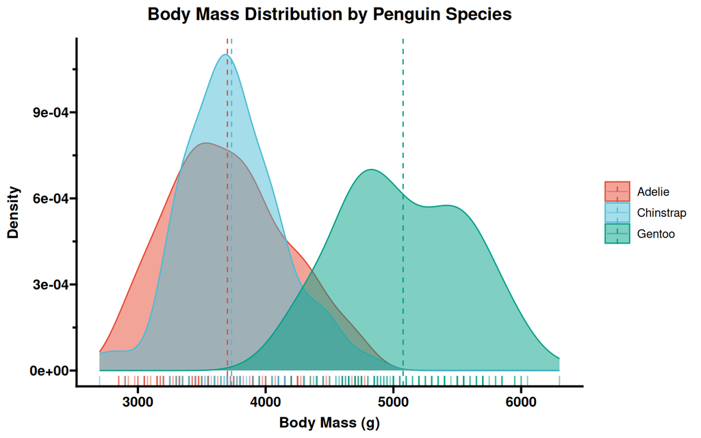

Figure 1: Kernel density estimates of body mass for three penguin species. Vertical dashed lines mark group means.

```r
ggdensity(penguins_clean, x = "body_mass_g",
          add = "mean", rug = TRUE,
          color = "species", fill = "species",
          palette = npg_3,
          xlab = "Body Mass (g)", ylab = "Density",
          title = "Body Mass Distribution by Penguin Species") +
  theme_prism(base_size = 12) +
  scale_y_continuous(guide = guide_prism_minor())
```

Gentoo penguins are clearly heavier on average, with a distribution shifted to the right relative to Adélie and Chinstrap.

### Histogram — Bill Length by Species

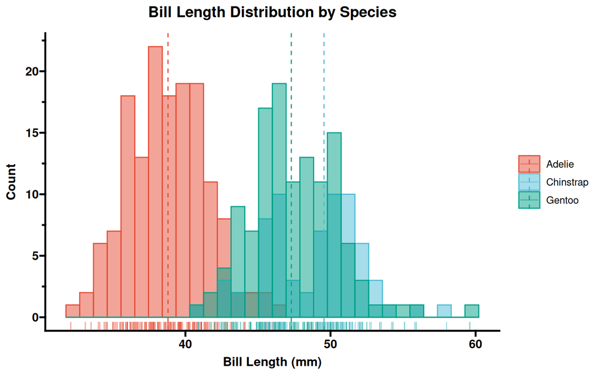

Figure 2: Overlaid histograms of bill length. Dashed lines indicate group medians.

```r
gghistogram(penguins_clean, x = "bill_length_mm",
            add = "median", rug = TRUE,
            color = "species", fill = "species",
            palette = npg_3,
            xlab = "Bill Length (mm)", ylab = "Count",
            title = "Bill Length Distribution by Species") +
  theme_prism(base_size = 12) +
  scale_y_continuous(guide = guide_prism_minor())
```

Adélie penguins cluster around shorter bill lengths (~38 mm), while Chinstrap and Gentoo show broader, higher distributions.

## Group Comparisons

### Box Plot with Significance Brackets

Adding statistical comparisons directly to a figure avoids the need for readers to cross-reference a separate table. `stat_compare_means()` performs Wilcoxon tests by default and overlays the results as brackets. The `guide_prism_bracket()` on the x-axis draws bracket-style category labels reminiscent of GraphPad Prism.

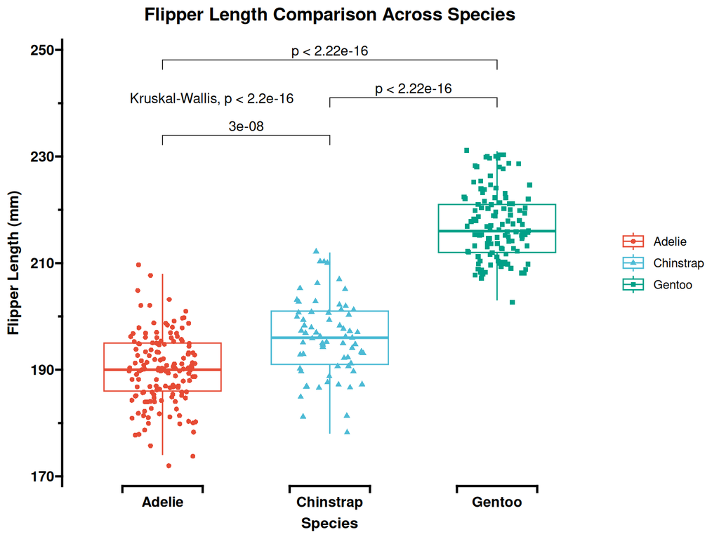

Figure 3: Flipper length by species with pairwise Wilcoxon tests and a global Kruskal–Wallis p-value.

```r
species_comparisons <- list(c("Adelie", "Chinstrap"),
                            c("Chinstrap", "Gentoo"),
                            c("Adelie", "Gentoo"))

ggboxplot(penguins_clean, x = "species", y = "flipper_length_mm",
          color = "species",
          palette = npg_3,
          add = "jitter", shape = "species",
          xlab = "Species", ylab = "Flipper Length (mm)",
          title = "Flipper Length Comparison Across Species") +
  stat_compare_means(comparisons = species_comparisons) +
  stat_compare_means(label.y = 240) +
  theme_prism(base_size = 12) +
  scale_y_continuous(guide = guide_prism_minor()) +
  scale_x_discrete(guide = guide_prism_bracket(width = 0.15))
```

All pairwise differences are highly significant, with Gentoo penguins having the longest flippers.

### Violin Plot with Nested Box Plot

Violin plots reveal the full distribution shape while a nested box plot preserves familiar summary statistics. Bracket-style x-axis labels keep the categorical axis clean.

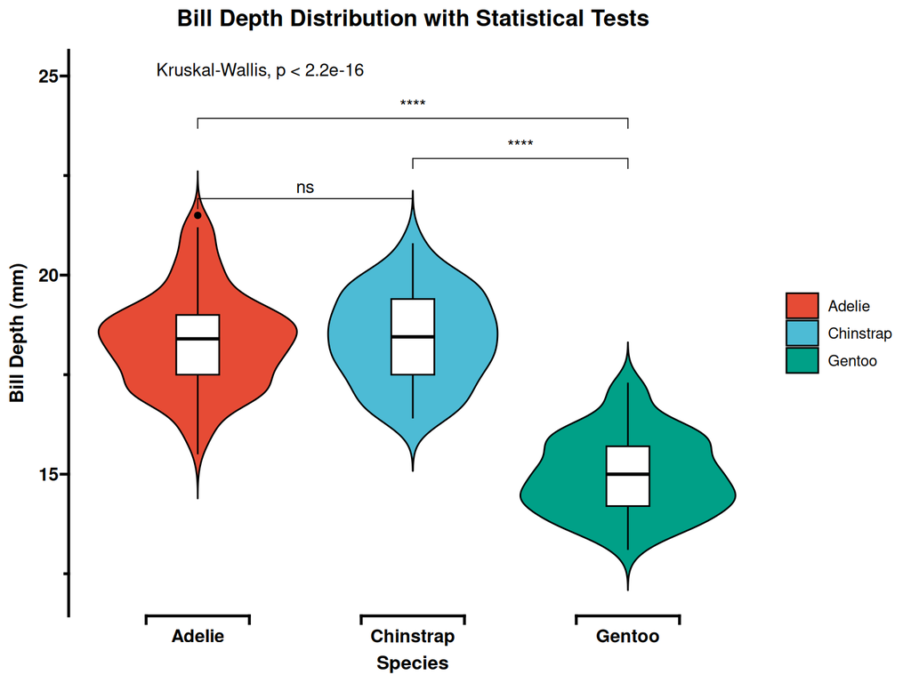

Figure 4: Bill depth distributions shown as violins with embedded box plots. Significance stars from pairwise Wilcoxon tests.

```r
ggviolin(penguins_clean, x = "species", y = "bill_depth_mm",
         fill = "species",
         palette = npg_3,
         add = "boxplot", add.params = list(fill = "white"),
         xlab = "Species", ylab = "Bill Depth (mm)",
         title = "Bill Depth Distribution with Statistical Tests") +
  stat_compare_means(comparisons = species_comparisons, label = "p.signif") +
  stat_compare_means(label.y = 25) +
  theme_prism(base_size = 12) +
  scale_y_continuous(guide = guide_prism_minor()) +
  scale_x_discrete(guide = guide_prism_bracket(width = 0.15))
```

## Scatter Plots with Regression

`ggscatter()` combines points, regression lines, confidence intervals, and correlation coefficients in a single call — useful for quickly assessing bivariate relationships across groups. Adding `guide_prism_minor()` to both axes gives the continuous scales a polished look.

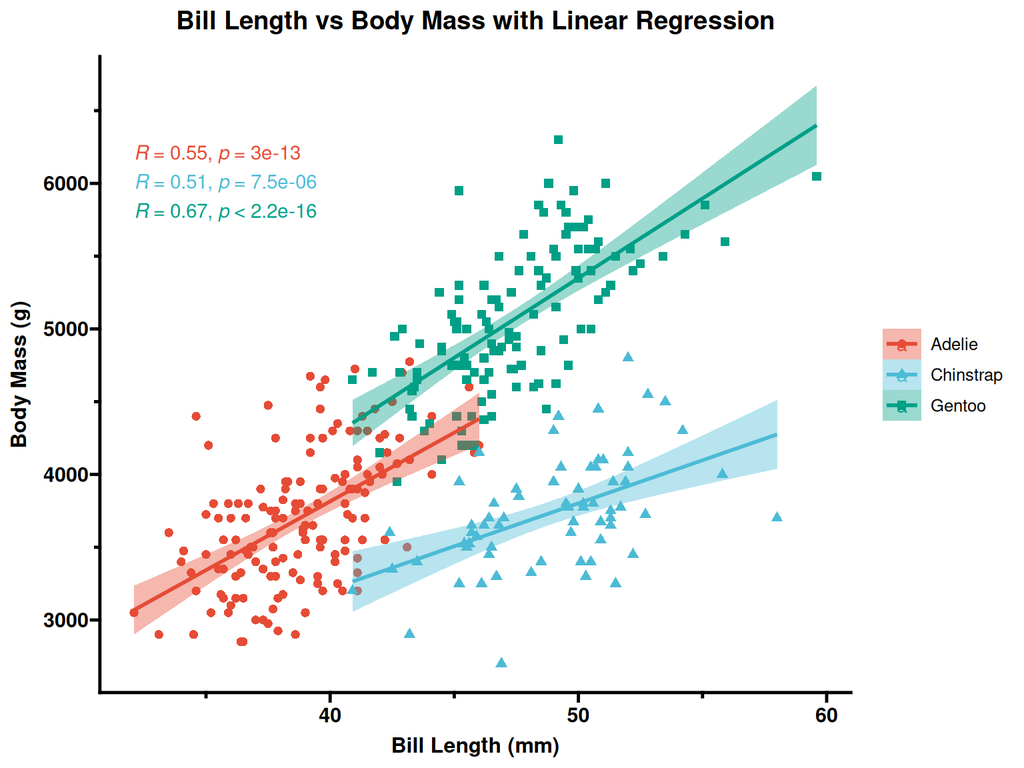

Figure 5: Bill length versus body mass with per-species linear regression and Pearson correlation.

```r
ggscatter(penguins_clean, x = "bill_length_mm", y = "body_mass_g",
          color = "species", shape = "species",
          palette = npg_3,
          add = "reg.line", conf.int = TRUE,
          xlab = "Bill Length (mm)", ylab = "Body Mass (g)",
          title = "Bill Length vs Body Mass with Linear Regression") +
  stat_cor(aes(color = species), label.y = c(6200, 6000, 5800)) +
  theme_prism(base_size = 12) +
  scale_x_continuous(guide = guide_prism_minor()) +
  scale_y_continuous(guide = guide_prism_minor())
```

Each species shows a positive relationship between bill length and body mass, though the slopes and correlation strengths differ.

## Bar Plots

### Ordered Bar Plot — Life Expectancy in the Americas

Bar plots remain a staple of scientific communication. Sorting bars by value and colouring by a derived grouping variable makes patterns immediately apparent.

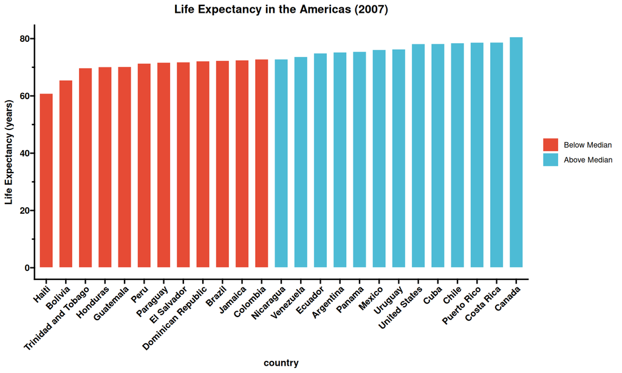

Figure 6: Life expectancy across countries in the Americas (2007), coloured by position relative to the regional median.

```r
americas_2007 <- gapminder |>
  filter(continent == "Americas", year == 2007) |>
  mutate(lifeExp_grp = factor(
    ifelse(lifeExp < median(lifeExp), "Below Median", "Above Median"),
    levels = c("Below Median", "Above Median")))

ggbarplot(americas_2007, x = "country", y = "lifeExp",
          fill = "lifeExp_grp",
          color = "white",
          palette = npg_2,
          sort.val = "asc",
          sort.by.groups = FALSE,
          x.text.angle = 90,
          xlab = FALSE,
          ylab = "Life Expectancy (years)",
          legend.title = "Group",
          title = "Life Expectancy in the Americas (2007)") +
  theme_prism(base_size = 11) +
  scale_y_continuous(guide = guide_prism_minor()) +
  theme(axis.text.x = element_text(angle = 45, hjust = 1, vjust = 1))
```

### Deviation Plot — GDP per Capita in Europe

Deviation plots highlight values above and below a reference point. Here we standardise GDP per capita to z-scores so that the zero line represents the European mean.

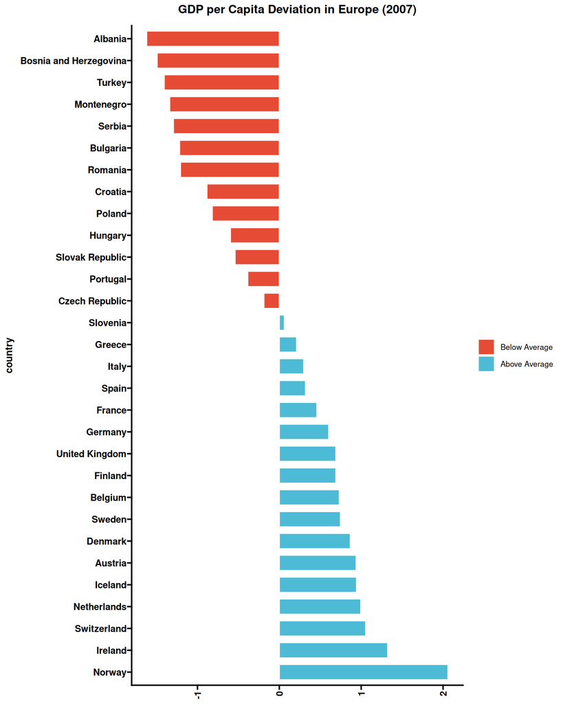

Figure 7: Z-scored GDP per capita across European countries (2007). Bars extend from the continental mean.

```r
europe_2007 <- gapminder |>
  filter(continent == "Europe", year == 2007) |>
  mutate(gdp_z = (gdpPercap - mean(gdpPercap)) / sd(gdpPercap),
         gdp_grp = factor(
           ifelse(gdp_z < 0, "Below Average", "Above Average"),
           levels = c("Below Average", "Above Average")))

ggbarplot(europe_2007, x = "country", y = "gdp_z",
          fill = "gdp_grp",
          color = "white",
          palette = npg_2,
          sort.val = "desc",
          sort.by.groups = FALSE,
          x.text.angle = 90,
          ylab = "GDP per Capita (z-score)",
          xlab = FALSE,
          legend.title = "GDP Group",
          title = "GDP per Capita Deviation in Europe (2007)",
          rotate = TRUE,
          ggtheme = theme_prism(base_size = 10))
```

Norway and Ireland stand out well above the continental average, while several Eastern European countries fall below.

## Dot Charts

### Lollipop Chart — GDP per Capita: Europe and the USA

When there are many categories, lollipop charts reduce visual clutter compared to full bars while preserving rank and magnitude. Here the USA is highlighted alongside European nations for a transatlantic comparison.

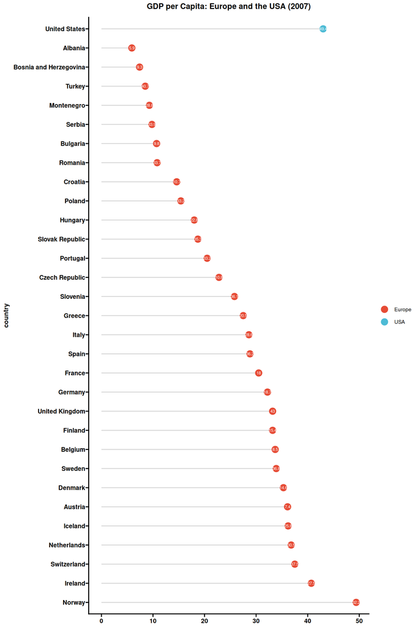

Figure 8: GDP per capita (thousands USD) across European countries and the USA in 2007.

```r
gdp_2007 <- gapminder |>
  filter((continent == "Europe" | country == "United States"), year == 2007) |>
  mutate(region = ifelse(country == "United States", "USA", "Europe"),
         gdpPercap_k = round(gdpPercap / 1000, 1))

ggdotchart(gdp_2007, x = "country", y = "gdpPercap_k",
           color = "region",
           palette = npg_2,
           sorting = "ascending",
           add = "segments",
           rotate = TRUE,
           group = "region",
           dot.size = 4,
           label = gdp_2007 |> arrange(gdpPercap_k) |> pull(gdpPercap_k),
           font.label = list(color = "white", size = 6, vjust = 0.5),
           xlab = FALSE, ylab = "GDP per Capita (thousands USD)",
           title = "GDP per Capita: Europe and the USA (2007)",
           ggtheme = theme_prism(base_size = 9))
```

Norway leads at ~49k USD, with the United States close behind. Several Eastern European countries sit at the lower end of the distribution.

### Cleveland Dot Plot — Iris Sepal Length

Cleveland dot plots order observations along one axis and use aligned dots for easy comparison. Colouring the y-axis labels by group reinforces the grouping.

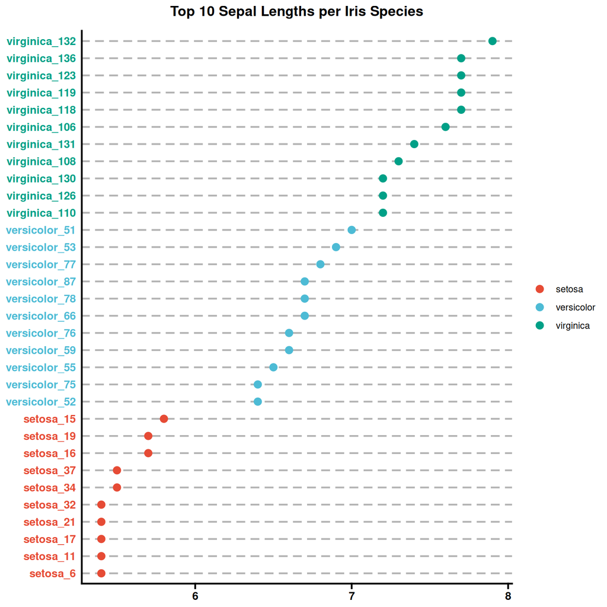

Figure 9: Top 10 sepal lengths within each iris species. Y-axis labels are colour-coded by species.

```r
iris_df <- iris |>
  mutate(name = paste(Species, row_number(), sep = "_")) |>
  group_by(Species) |>
  slice_max(order_by = Sepal.Length, n = 10) |>
  ungroup()

ggdotchart(iris_df, x = "name", y = "Sepal.Length",
           color = "Species",
           palette = npg_3,
           sorting = "descending",
           rotate = TRUE,
           dot.size = 3,
           y.text.col = TRUE,
           xlab = FALSE, ylab = "Sepal Length (cm)",
           title = "Top 10 Sepal Lengths per Iris Species",
           ggtheme = theme_prism(base_size = 11)) +
  theme_cleveland()
```

## Multi-Panel Figures

Journals frequently require composite figures. `ggarrange()` handles layout, shared legends, and panel labelling. Applying `theme_prism()` with `guide_prism_bracket()` to each sub-plot ensures consistent styling across panels.

### Morphometrics by Island

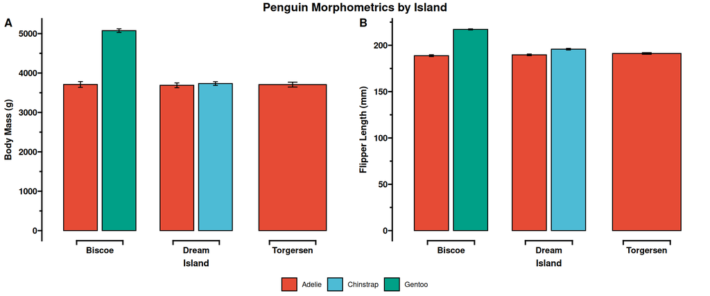

Figure 10: Mean body mass (A) and flipper length (B) by island, grouped by species. Error bars show ± 1 SE.

```r
p_mass <- ggbarplot(penguins_clean, x = "island", y = "body_mass_g",
                    add = "mean_se", fill = "species",
                    palette = npg_3,
                    position = position_dodge(0.8),
                    ylab = "Body Mass (g)", xlab = "Island") +
  theme_prism(base_size = 11) +
  scale_y_continuous(guide = guide_prism_minor()) +
  scale_x_discrete(guide = guide_prism_bracket(width = 0.15))

p_flip <- ggbarplot(penguins_clean, x = "island", y = "flipper_length_mm",
                    add = "mean_se", fill = "species",
                    palette = npg_3,
                    position = position_dodge(0.8),
                    ylab = "Flipper Length (mm)", xlab = "Island") +
  theme_prism(base_size = 11) +
  scale_y_continuous(guide = guide_prism_minor()) +
  scale_x_discrete(guide = guide_prism_bracket(width = 0.15))

combined <- ggarrange(p_mass, p_flip, ncol = 2,
                      common.legend = TRUE, legend = "bottom",
                      labels = c("A", "B"))
annotate_figure(combined,
                top = text_grob("Penguin Morphometrics by Island",
                                face = "bold", size = 14))
```

## Faceted Plots

Faceting splits data into panels by a grouping variable, making it easy to compare patterns across subsets without overplotting.

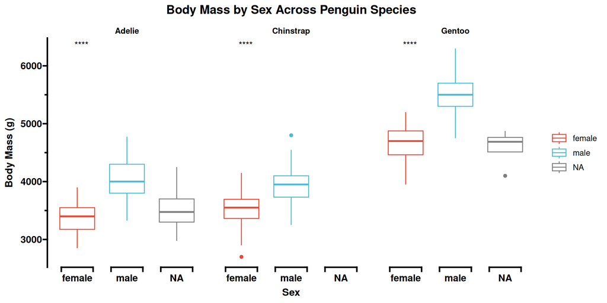

Figure 11: Body mass by sex within each species. Significance stars from Wilcoxon tests.

```r
ggboxplot(penguins_clean, x = "sex", y = "body_mass_g",
          color = "sex", palette = npg_2,
          facet.by = "species",
          xlab = "Sex", ylab = "Body Mass (g)",
          title = "Body Mass by Sex Across Penguin Species") +
  stat_compare_means(label = "p.signif") +
  theme_prism(base_size = 12) +
  scale_y_continuous(guide = guide_prism_minor()) +
  scale_x_discrete(guide = guide_prism_bracket(width = 0.2))
```

Males are significantly heavier than females in all three species, with the largest dimorphism in Gentoo.

## Summary

This report covered the following ggpubr + ggprism capabilities:

| Technique | Function(s) | ggprism Enhancement |
| --- | --- | --- |
| Density plots | `ggdensity()` | `theme_prism()`, minor tick guides |
| Histograms | `gghistogram()` | `theme_prism()`, minor tick guides |
| Box plots + stats | `ggboxplot()` + `stat_compare_means()` | `theme_prism()`, bracket axis, minor tick guides |
| Violin plots | `ggviolin()` | `theme_prism()`, bracket axis, minor tick guides |
| Scatter + regression | `ggscatter()` + `stat_cor()` | `theme_prism()`, minor tick guides on both axes |
| Ordered bar plots | `ggbarplot()` | `theme_prism()`, minor tick guides |
| Deviation plots | `ggbarplot()` | `theme_prism()` |
| Lollipop charts | `ggdotchart()` | `theme_prism()` |
| Cleveland dot plots | `ggdotchart()` + `theme_cleveland()` | `theme_prism()` |
| Multi-panel figures | `ggarrange()` + `annotate_figure()` | `theme_prism()`, bracket axis, minor tick guides |
| Faceting | `facet.by` argument | `theme_prism()`, bracket axis, minor tick guides |

All figures use the **NPG (Nature Publishing Group)** colour palette and were generated from publicly available datasets with no manual data manipulation beyond filtering and standardisation. Each plot type can be further customised through standard ggplot2 layers or `ggpar()`.